#White noise

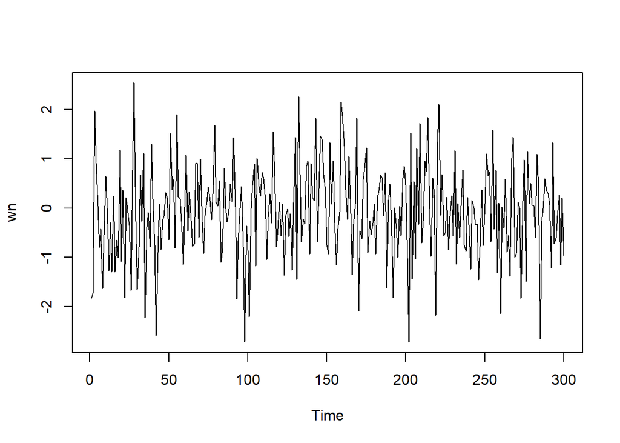

```r
wn <- rnorm(300)
ts.plot(wn)
```

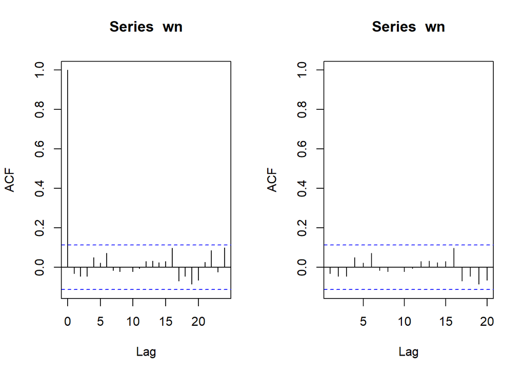

```r
par(mfrow = c(1, 2))
acf(wn)
acf(wn, xlim = c(1, 20))
```

## Proses MA

```r
set.seed(060)
ma <- NULL
ma[1] <- wn[1]
ma[2] <- wn[2]
```

```r
for(i in 3:300){
   ma[i] <- wn[i] + 0.4 * wn[i - 1] + 0.6 * wn[i - 2]
}
ma
```

```
##   [1] -1.83029633 -1.73949567  0.17712950  0.65894289  1.59079612 -0.23301791
##   [7] -0.71802108 -2.28118358 -1.45696365 -0.55238040 -0.07448970 -0.88528894
##  [13] -0.80758115 -2.17383738 -0.45682752 -1.97307256 -1.02575027 -2.04407264
##  [19]  0.38620879 -1.21246551  0.64109988 -2.32205388 -0.29573902 -1.09980086
##  [25] -0.25944076 -1.86171238 -0.10198668  1.85374262  1.21765505 -0.22871989
##  [31] -1.60491096 -0.61727266 -0.46392596  1.41533317 -1.94212065 -0.60319026
##  [37] -1.57482504 -1.05298870  0.93247993  0.23256294  0.10607323 -2.77491528
##  [43] -2.38706255 -1.83197160 -1.34798100 -0.52679138 -0.76423210  0.10979223
##  [49]  0.25507063 -0.35840152  1.39327793  0.59845764  1.64227073 -0.34516041
##  [55]  1.93154460  0.50772830  1.43138530 -0.05019273 -1.13374925 -0.59432235
##  [61]  0.40038747 -0.01409582  0.79369370 -0.39102346 -0.67229079 -1.18299922
##  [67]  0.15683979  0.84666377  0.32330525  1.31276831 -0.22888520 -0.43338211
##  [73] -0.68519515 -0.48459101  0.38711823  0.40587234  0.08623260  0.47182524
##  [79]  1.73203841  1.06437908  1.09990912  0.64156325 -0.84467722 -0.93351134
##  [85] -0.18552744 -0.19177997  0.19954787 -0.14428832  0.31209250  0.31343885
```

[output cut: 35 more lines]

Selain menggunakan cara di atas, pembangkitan proses MA(2) dapat dilakukan dengan fungsi `arima.sim()` sebagai berikut.

```r
ma1 <- arima.sim(list(order=c(0,0,2), ma=c(0.4,0.6)), n=300)
ma1
```

```
## Time Series:
## Start = 1
## End = 300
## Frequency = 1
##   [1]  0.057260360 -0.083687065 -2.139682871 -2.507185217 -0.651611992
##   [6] -0.278450401 -0.130002013  0.271623445 -0.569634089  0.169612654
##  [11]  1.238032579 -0.053956349  0.188045337  1.025238822  0.181239713
##  [16]  1.437158445 -0.209918856  0.667036946 -0.311600246 -0.341028454
##  [21]  0.307396959  0.670828218  0.989073946  0.981968313  0.131280732
##  [26] -1.568824790  1.339890500  1.452150909  1.679794071  2.495451321
##  [31]  0.363831609  0.389406134  0.082039709 -1.670620653 -1.152824706
##  [36] -2.132836957 -0.443781678 -0.575813584  1.991661939  1.822386955
##  [41]  1.981522328  1.277877602  0.967576165  1.499024015 -1.401491245
##  [46] -0.169987096  0.898868569  1.808203485  3.367480409  2.845078066
##  [51]  2.750973033  1.348231923  1.095103669 -1.239060394 -0.573070554
```

[output cut: 49 more lines]

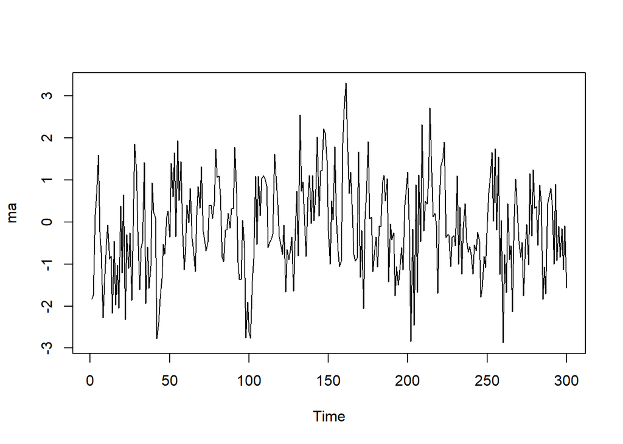

```r
ts.plot(ma)
```

###Plot ACF

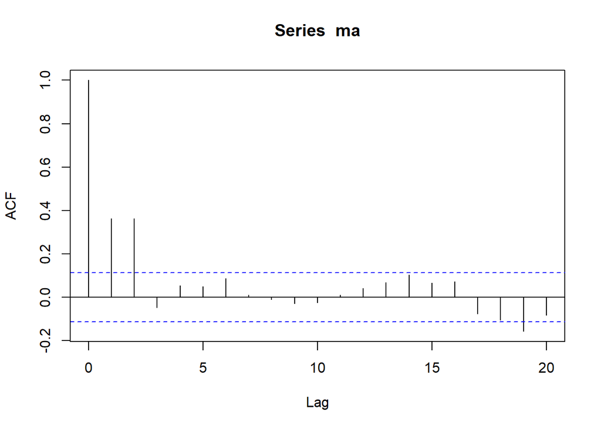

```r
acf(ma,lag.max = 20)
```

###Plot PACF

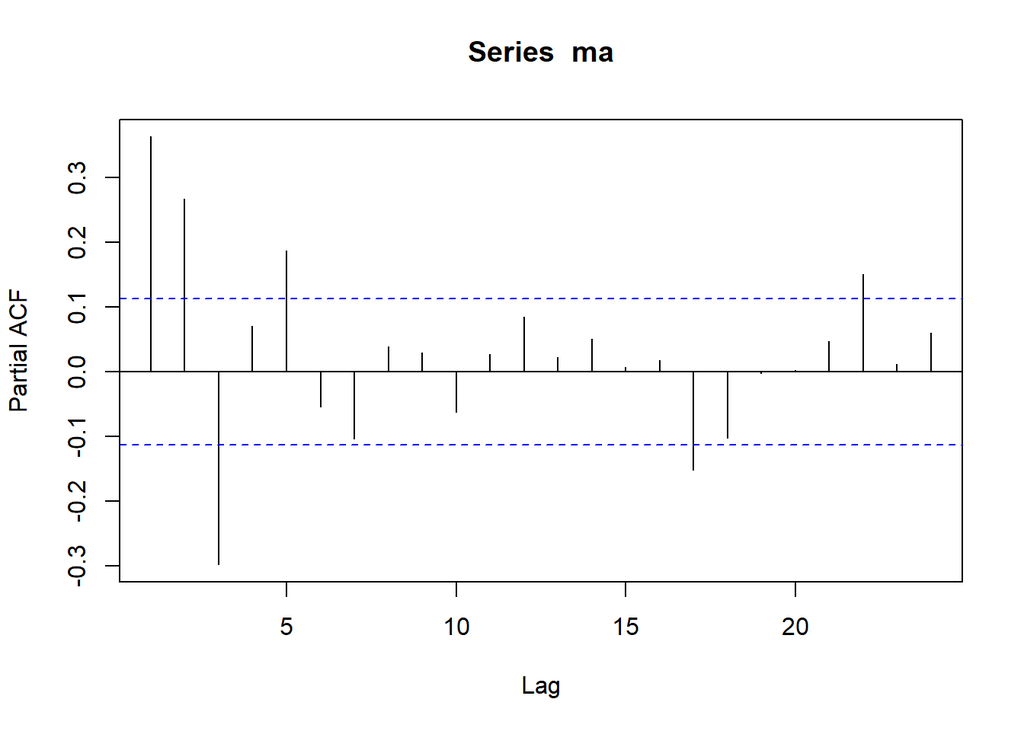

```r
pacf(ma)
```

###Plot EACF

```r
TSA::eacf(ma)
```

```
## AR/MA
##   0 1 2 3 4 5 6 7 8 9 10 11 12 13
## 0 x x o o o o o o o o o  o  o  o
## 1 x x x o o o o o o o o  o  o  o
## 2 x x x o o o o o o o o  o  o  o
## 3 x x x o x o o o o o o  o  o  o
## 4 x x o o x x o o o o o  o  o  o
## 5 x x o o o x o o o o o  o  o  o
## 6 x x o o o o o o o o o  o  o  o
## 7 x x x o o o o o o o o  o  o  o
```

###Scatterplot Antar Lag

####Korelasi antara $Y_t$ dengan $Y_{t-1}$

```r
#Yt
yt_ma <- ma[-1]
yt_ma
```

```
##   [1] -1.73949567  0.17712950  0.65894289  1.59079612 -0.23301791 -0.71802108
##   [7] -2.28118358 -1.45696365 -0.55238040 -0.07448970 -0.88528894 -0.80758115
##  [13] -2.17383738 -0.45682752 -1.97307256 -1.02575027 -2.04407264  0.38620879
##  [19] -1.21246551  0.64109988 -2.32205388 -0.29573902 -1.09980086 -0.25944076
##  [25] -1.86171238 -0.10198668  1.85374262  1.21765505 -0.22871989 -1.60491096
##  [31] -0.61727266 -0.46392596  1.41533317 -1.94212065 -0.60319026 -1.57482504
##  [37] -1.05298870  0.93247993  0.23256294  0.10607323 -2.77491528 -2.38706255
##  [43] -1.83197160 -1.34798100 -0.52679138 -0.76423210  0.10979223  0.25507063
##  [49] -0.35840152  1.39327793  0.59845764  1.64227073 -0.34516041  1.93154460
##  [55]  0.50772830  1.43138530 -0.05019273 -1.13374925 -0.59432235  0.40038747
##  [61] -0.01409582  0.79369370 -0.39102346 -0.67229079 -1.18299922  0.15683979
##  [67]  0.84666377  0.32330525  1.31276831 -0.22888520 -0.43338211 -0.68519515
##  [73] -0.48459101  0.38711823  0.40587234  0.08623260  0.47182524  1.73203841
##  [79]  1.06437908  1.09990912  0.64156325 -0.84467722 -0.93351134 -0.18552744
##  [85] -0.19177997  0.19954787 -0.14428832  0.31209250  0.31343885  1.78066751
```

[output cut: 35 more lines]

```r
#Yt-1
yt_1_ma <- ma[-300]
yt_1_ma
```

```
##   [1] -1.83029633 -1.73949567  0.17712950  0.65894289  1.59079612 -0.23301791
##   [7] -0.71802108 -2.28118358 -1.45696365 -0.55238040 -0.07448970 -0.88528894
##  [13] -0.80758115 -2.17383738 -0.45682752 -1.97307256 -1.02575027 -2.04407264
##  [19]  0.38620879 -1.21246551  0.64109988 -2.32205388 -0.29573902 -1.09980086
##  [25] -0.25944076 -1.86171238 -0.10198668  1.85374262  1.21765505 -0.22871989
##  [31] -1.60491096 -0.61727266 -0.46392596  1.41533317 -1.94212065 -0.60319026
##  [37] -1.57482504 -1.05298870  0.93247993  0.23256294  0.10607323 -2.77491528
##  [43] -2.38706255 -1.83197160 -1.34798100 -0.52679138 -0.76423210  0.10979223
##  [49]  0.25507063 -0.35840152  1.39327793  0.59845764  1.64227073 -0.34516041
##  [55]  1.93154460  0.50772830  1.43138530 -0.05019273 -1.13374925 -0.59432235
##  [61]  0.40038747 -0.01409582  0.79369370 -0.39102346 -0.67229079 -1.18299922
##  [67]  0.15683979  0.84666377  0.32330525  1.31276831 -0.22888520 -0.43338211
##  [73] -0.68519515 -0.48459101  0.38711823  0.40587234  0.08623260  0.47182524
##  [79]  1.73203841  1.06437908  1.09990912  0.64156325 -0.84467722 -0.93351134
##  [85] -0.18552744 -0.19177997  0.19954787 -0.14428832  0.31209250  0.31343885
```

[output cut: 35 more lines]

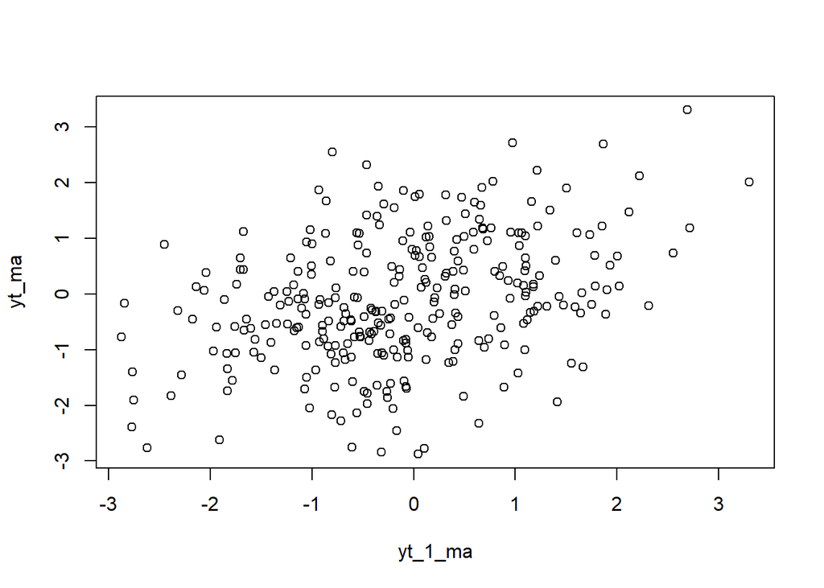

```r
plot(y=yt_ma,x=yt_1_ma)
```

Berdasarkan scatterplot tersebut, terlihat bahwa terdapat hubungan positif antara $Y_t$ dengan $Y_{t-1}$.

```r
cor(yt_ma,yt_1_ma)
```

```
## [1] 0.3648754
```

###Korelasi antara $Y_t$ dengan $Y_{t-2}$

```r
#Yt
yt_ma2 <- ma[-c(1,2)]
yt_ma2
```

```
##   [1]  0.17712950  0.65894289  1.59079612 -0.23301791 -0.71802108 -2.28118358
##   [7] -1.45696365 -0.55238040 -0.07448970 -0.88528894 -0.80758115 -2.17383738
##  [13] -0.45682752 -1.97307256 -1.02575027 -2.04407264  0.38620879 -1.21246551
##  [19]  0.64109988 -2.32205388 -0.29573902 -1.09980086 -0.25944076 -1.86171238
##  [25] -0.10198668  1.85374262  1.21765505 -0.22871989 -1.60491096 -0.61727266
##  [31] -0.46392596  1.41533317 -1.94212065 -0.60319026 -1.57482504 -1.05298870
##  [37]  0.93247993  0.23256294  0.10607323 -2.77491528 -2.38706255 -1.83197160
##  [43] -1.34798100 -0.52679138 -0.76423210  0.10979223  0.25507063 -0.35840152
##  [49]  1.39327793  0.59845764  1.64227073 -0.34516041  1.93154460  0.50772830
##  [55]  1.43138530 -0.05019273 -1.13374925 -0.59432235  0.40038747 -0.01409582
##  [61]  0.79369370 -0.39102346 -0.67229079 -1.18299922  0.15683979  0.84666377
##  [67]  0.32330525  1.31276831 -0.22888520 -0.43338211 -0.68519515 -0.48459101
##  [73]  0.38711823  0.40587234  0.08623260  0.47182524  1.73203841  1.06437908
##  [79]  1.09990912  0.64156325 -0.84467722 -0.93351134 -0.18552744 -0.19177997
##  [85]  0.19954787 -0.14428832  0.31209250  0.31343885  1.78066751  0.69277011
```

[output cut: 35 more lines]

```r
#Yt-2
yt_2_ma <- ma[-c(299,300)]
yt_2_ma
```

```
##   [1] -1.83029633 -1.73949567  0.17712950  0.65894289  1.59079612 -0.23301791
##   [7] -0.71802108 -2.28118358 -1.45696365 -0.55238040 -0.07448970 -0.88528894
##  [13] -0.80758115 -2.17383738 -0.45682752 -1.97307256 -1.02575027 -2.04407264
##  [19]  0.38620879 -1.21246551  0.64109988 -2.32205388 -0.29573902 -1.09980086
##  [25] -0.25944076 -1.86171238 -0.10198668  1.85374262  1.21765505 -0.22871989
##  [31] -1.60491096 -0.61727266 -0.46392596  1.41533317 -1.94212065 -0.60319026
##  [37] -1.57482504 -1.05298870  0.93247993  0.23256294  0.10607323 -2.77491528
##  [43] -2.38706255 -1.83197160 -1.34798100 -0.52679138 -0.76423210  0.10979223
##  [49]  0.25507063 -0.35840152  1.39327793  0.59845764  1.64227073 -0.34516041
##  [55]  1.93154460  0.50772830  1.43138530 -0.05019273 -1.13374925 -0.59432235
##  [61]  0.40038747 -0.01409582  0.79369370 -0.39102346 -0.67229079 -1.18299922
##  [67]  0.15683979  0.84666377  0.32330525  1.31276831 -0.22888520 -0.43338211
##  [73] -0.68519515 -0.48459101  0.38711823  0.40587234  0.08623260  0.47182524
##  [79]  1.73203841  1.06437908  1.09990912  0.64156325 -0.84467722 -0.93351134
##  [85] -0.18552744 -0.19177997  0.19954787 -0.14428832  0.31209250  0.31343885
```

[output cut: 35 more lines]

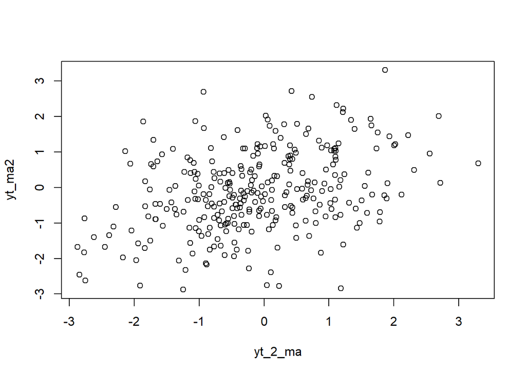

```r
plot(y=yt_ma2,x=yt_2_ma)
```

```r
cor(yt_ma2,yt_2_ma)
```

```
## [1] 0.3663401
```

###Korelasi antara $Y_t$ dengan $Y_{t-3}$

```r
#Yt
yt_ma3 <- ma[-c(1,2,3)]
yt_ma3
```

```
##   [1]  0.65894289  1.59079612 -0.23301791 -0.71802108 -2.28118358 -1.45696365
##   [7] -0.55238040 -0.07448970 -0.88528894 -0.80758115 -2.17383738 -0.45682752
##  [13] -1.97307256 -1.02575027 -2.04407264  0.38620879 -1.21246551  0.64109988
##  [19] -2.32205388 -0.29573902 -1.09980086 -0.25944076 -1.86171238 -0.10198668
##  [25]  1.85374262  1.21765505 -0.22871989 -1.60491096 -0.61727266 -0.46392596
##  [31]  1.41533317 -1.94212065 -0.60319026 -1.57482504 -1.05298870  0.93247993
##  [37]  0.23256294  0.10607323 -2.77491528 -2.38706255 -1.83197160 -1.34798100
##  [43] -0.52679138 -0.76423210  0.10979223  0.25507063 -0.35840152  1.39327793
##  [49]  0.59845764  1.64227073 -0.34516041  1.93154460  0.50772830  1.43138530
##  [55] -0.05019273 -1.13374925 -0.59432235  0.40038747 -0.01409582  0.79369370
##  [61] -0.39102346 -0.67229079 -1.18299922  0.15683979  0.84666377  0.32330525
##  [67]  1.31276831 -0.22888520 -0.43338211 -0.68519515 -0.48459101  0.38711823
##  [73]  0.40587234  0.08623260  0.47182524  1.73203841  1.06437908  1.09990912
##  [79]  0.64156325 -0.84467722 -0.93351134 -0.18552744 -0.19177997  0.19954787
##  [85] -0.14428832  0.31209250  0.31343885  1.78066751  0.69277011 -0.96248343
```

[output cut: 35 more lines]

```r
#Yt-2
yt_3_ma <- ma[-c(298,299,300)]
yt_3_ma
```

```
##   [1] -1.83029633 -1.73949567  0.17712950  0.65894289  1.59079612 -0.23301791
##   [7] -0.71802108 -2.28118358 -1.45696365 -0.55238040 -0.07448970 -0.88528894
##  [13] -0.80758115 -2.17383738 -0.45682752 -1.97307256 -1.02575027 -2.04407264
##  [19]  0.38620879 -1.21246551  0.64109988 -2.32205388 -0.29573902 -1.09980086
##  [25] -0.25944076 -1.86171238 -0.10198668  1.85374262  1.21765505 -0.22871989
##  [31] -1.60491096 -0.61727266 -0.46392596  1.41533317 -1.94212065 -0.60319026
##  [37] -1.57482504 -1.05298870  0.93247993  0.23256294  0.10607323 -2.77491528
##  [43] -2.38706255 -1.83197160 -1.34798100 -0.52679138 -0.76423210  0.10979223
##  [49]  0.25507063 -0.35840152  1.39327793  0.59845764  1.64227073 -0.34516041
##  [55]  1.93154460  0.50772830  1.43138530 -0.05019273 -1.13374925 -0.59432235
##  [61]  0.40038747 -0.01409582  0.79369370 -0.39102346 -0.67229079 -1.18299922
##  [67]  0.15683979  0.84666377  0.32330525  1.31276831 -0.22888520 -0.43338211
##  [73] -0.68519515 -0.48459101  0.38711823  0.40587234  0.08623260  0.47182524
##  [79]  1.73203841  1.06437908  1.09990912  0.64156325 -0.84467722 -0.93351134
##  [85] -0.18552744 -0.19177997  0.19954787 -0.14428832  0.31209250  0.31343885
```

[output cut: 35 more lines]

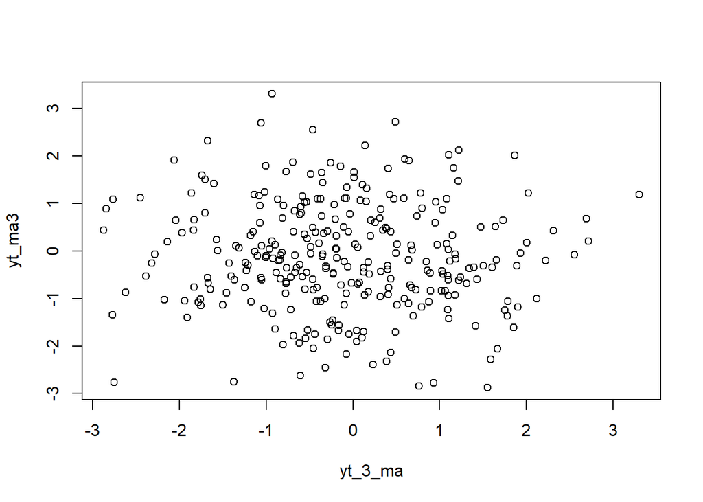

```r
plot(y=yt_ma3,x=yt_3_ma)
```

```r
cor(yt_ma3,yt_3_ma)
```

```
## [1] -0.04762125
```

##Proses AR

```r
set.seed(060)
```

```r
n<-length(wn)
n
```

```
## [1] 300
```

```r
ar <- c(1:n)
for (i in 2:n) {ar[i]<-wn[i]+0.5*ar[i-1]+0.2*ar[i-1]}
ar
```

```
##   [1]  1.000000000 -1.039495666  1.243458595  1.784619084  1.291686916
##   [6]  0.105662673 -0.350122073 -1.877523754 -1.863803390 -0.657765088
##  [11] -0.463962118 -1.596790168 -1.414411664 -2.282052112 -1.359483292
##  [16] -2.244713772 -2.222591630 -2.563524708 -0.614399085 -1.509945818
##  [21] -0.691956531 -2.304505798 -1.399841912 -1.072933323 -1.101263776
##  [26] -2.436686453 -0.931220206  1.891585437  1.059712833 -0.907225867
##  [31] -1.421720938 -0.308397269 -0.482529306  0.772138706 -1.685596517
##  [36] -1.558615912 -1.178720673 -1.615798351  0.170312359  0.305649433
##  [41] -0.535367198 -2.961802067 -2.975912909 -2.001823031 -2.240192648
##  [46] -1.808149222 -1.430580889 -0.681655194 -0.251062722 -0.816434647
##  [51]  0.942392425  1.036988108  1.308899032  0.111477925  1.981675295
##  [56]  1.616295548  1.328958603  0.663583897 -0.681096707 -0.452835594
##  [61]  0.761192978  0.073108845  0.381853653  0.019838852 -0.757826590
##  [66] -1.256317093  0.030781486  0.939632522  0.067691753  1.045321653
##  [71]  0.457695594 -0.602145821 -0.573266396 -0.271652114  0.236166595
```

[output cut: 45 more lines]

```r
ar1 <- arima.sim(list(order=c(2,0,0), ar=c(0.5,0.2)), n=300)
ar1
```

```
## Time Series:
## Start = 1
## End = 300
## Frequency = 1
##   [1]  1.08024580  0.49004163 -1.28246558  1.63156497  2.18764584  1.14371373
##   [7]  2.63839235  1.42602131  0.70145852  1.00681604 -0.85173557 -1.00168468
##  [13] -1.59589319 -0.60587566 -0.80007096  1.30618840  1.69128005  1.51268061
##  [19]  1.49123273  1.61359234  2.13990894 -0.76202871  0.11794126  2.06986492
##  [25]  1.95881989  3.10276365  3.56429207  3.47958486  2.39744057  2.36569338
##  [31]  0.26797813  0.30916618  0.18435613 -0.44271158 -0.12232707 -0.16194214
##  [37] -1.39012638 -1.70582234 -2.84284436 -0.59199805 -0.40221002 -0.80304270
##  [43] -1.03770592  0.12419360  0.74714680  1.17727535  1.38886524  0.87355501
##  [49]  1.22667327  0.94233593  1.26287188  1.01290727 -0.36483487 -0.47962192
##  [55] -1.29150626 -0.51451143  1.19370250  2.58992869  2.87594344  1.68895164
##  [61]  1.90849969  0.55284492 -0.44599064 -0.09915829 -0.80747541 -0.62699428
```

[output cut: 39 more lines]

##Karakteristik AR(2) ###Plot Time Series

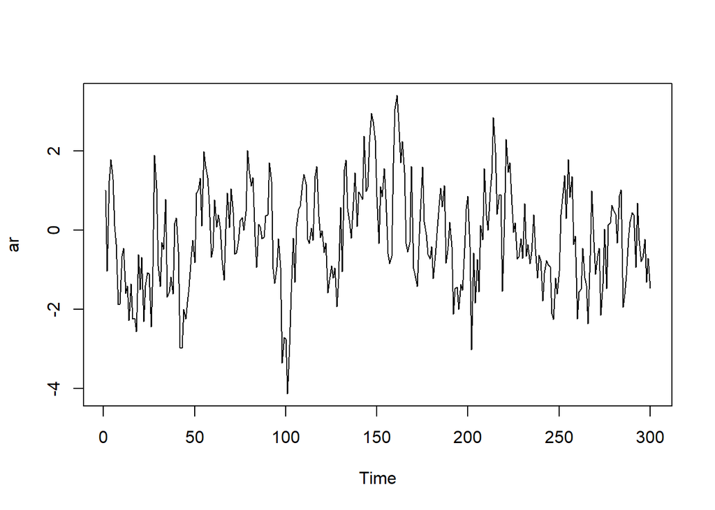

```r
ts.plot(ar)
```

###Plot ACF

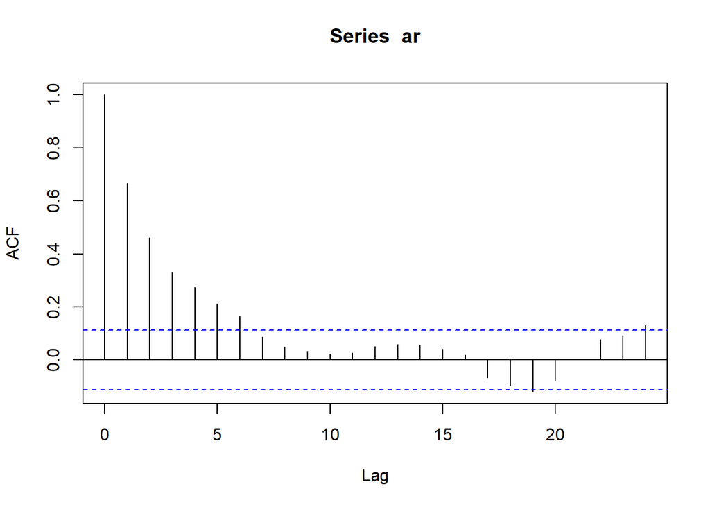

```r
acf(ar)
```

###Plot PACF

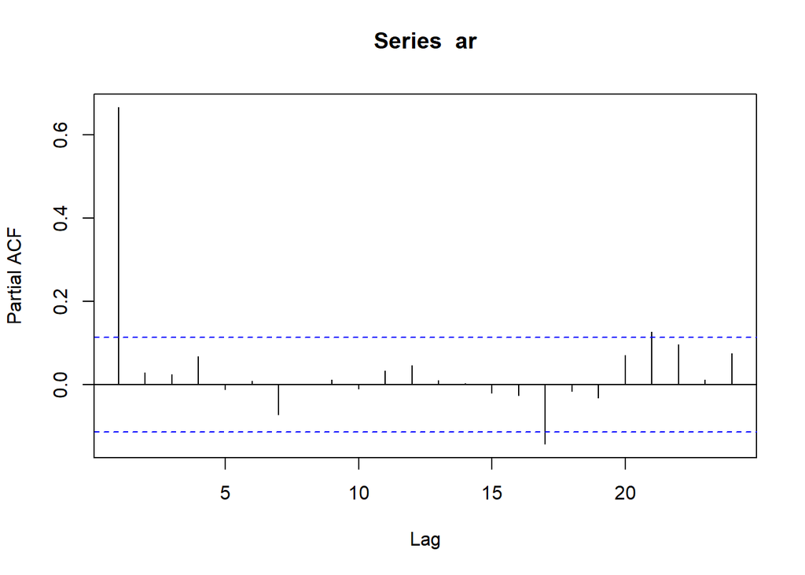

```r
pacf(ar)
```

Berdasarkan plot PACF tersebut, terlihat bahwa plot PACF *cuts off* pada lag pertama.

###Plot EACF

```r
TSA::eacf(ar)
```

```
## AR/MA
##   0 1 2 3 4 5 6 7 8 9 10 11 12 13
## 0 x x x x x x o o o o o  o  o  o
## 1 o o o o o o o o o o o  o  o  o
## 2 x o o o o o o o o o o  o  o  o
## 3 x o o o o o o o o o o  o  o  o
## 4 x o x o o o o o o o o  o  o  o
## 5 x o x x o o o o o o o  o  o  o
## 6 o o x x o o o o o o o  o  o  o
## 7 o x x x x o o o o o o  o  o  o
```

###Scatterplot Antar Lag ####Korelasi antara $Y_t$ dengan $Y_{t-1}$

```r
#Yt
yt_ar <- ar[-1]
yt_ar
```

```
##   [1] -1.039495666  1.243458595  1.784619084  1.291686916  0.105662673
##   [6] -0.350122073 -1.877523754 -1.863803390 -0.657765088 -0.463962118
##  [11] -1.596790168 -1.414411664 -2.282052112 -1.359483292 -2.244713772
##  [16] -2.222591630 -2.563524708 -0.614399085 -1.509945818 -0.691956531
##  [21] -2.304505798 -1.399841912 -1.072933323 -1.101263776 -2.436686453
##  [26] -0.931220206  1.891585437  1.059712833 -0.907225867 -1.421720938
##  [31] -0.308397269 -0.482529306  0.772138706 -1.685596517 -1.558615912
##  [36] -1.178720673 -1.615798351  0.170312359  0.305649433 -0.535367198
##  [41] -2.961802067 -2.975912909 -2.001823031 -2.240192648 -1.808149222
##  [46] -1.430580889 -0.681655194 -0.251062722 -0.816434647  0.942392425
##  [51]  1.036988108  1.308899032  0.111477925  1.981675295  1.616295548
##  [56]  1.328958603  0.663583897 -0.681096707 -0.452835594  0.761192978
##  [61]  0.073108845  0.381853653  0.019838852 -0.757826590 -1.256317093
##  [66]  0.030781486  0.939632522  0.067691753  1.045321653  0.457695594
##  [71] -0.602145821 -0.573266396 -0.271652114  0.236166595  0.322879110
```

[output cut: 45 more lines]

```r
#Yt-1
yt_1_ar <- ar[-300]
yt_1_ar
```

```
##   [1]  1.000000000 -1.039495666  1.243458595  1.784619084  1.291686916
##   [6]  0.105662673 -0.350122073 -1.877523754 -1.863803390 -0.657765088
##  [11] -0.463962118 -1.596790168 -1.414411664 -2.282052112 -1.359483292
##  [16] -2.244713772 -2.222591630 -2.563524708 -0.614399085 -1.509945818
##  [21] -0.691956531 -2.304505798 -1.399841912 -1.072933323 -1.101263776
##  [26] -2.436686453 -0.931220206  1.891585437  1.059712833 -0.907225867
##  [31] -1.421720938 -0.308397269 -0.482529306  0.772138706 -1.685596517
##  [36] -1.558615912 -1.178720673 -1.615798351  0.170312359  0.305649433
##  [41] -0.535367198 -2.961802067 -2.975912909 -2.001823031 -2.240192648
##  [46] -1.808149222 -1.430580889 -0.681655194 -0.251062722 -0.816434647
##  [51]  0.942392425  1.036988108  1.308899032  0.111477925  1.981675295
##  [56]  1.616295548  1.328958603  0.663583897 -0.681096707 -0.452835594
##  [61]  0.761192978  0.073108845  0.381853653  0.019838852 -0.757826590
##  [66] -1.256317093  0.030781486  0.939632522  0.067691753  1.045321653
##  [71]  0.457695594 -0.602145821 -0.573266396 -0.271652114  0.236166595
```

[output cut: 45 more lines]

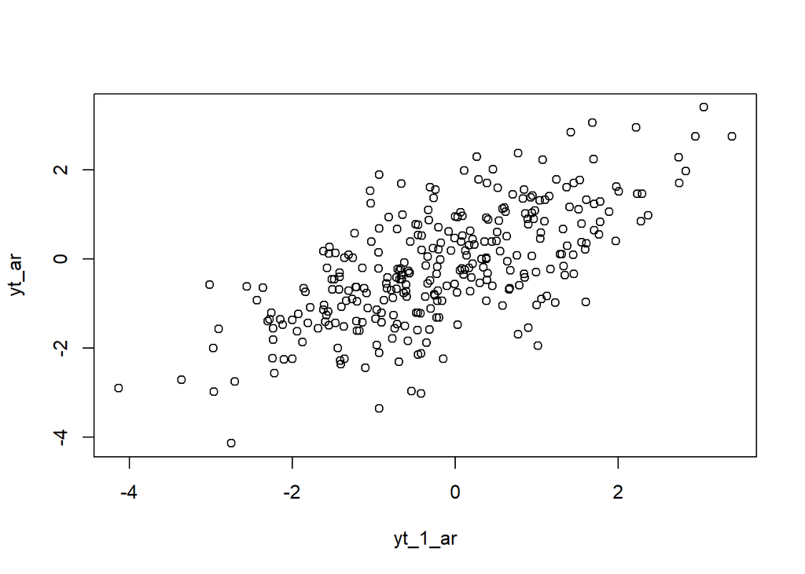

```r
plot(y=yt_ar,x=yt_1_ar)
```

```r
cor(yt_ar,yt_1_ar)
```

```
## [1] 0.6683608
```

####Korelasi antara $Y_t$ dengan $Y_{t-2}$

```r
#Yt
yt_ar2 <- ar[-c(1,2)]
yt_ar2
```

```
##   [1]  1.243458595  1.784619084  1.291686916  0.105662673 -0.350122073
##   [6] -1.877523754 -1.863803390 -0.657765088 -0.463962118 -1.596790168
##  [11] -1.414411664 -2.282052112 -1.359483292 -2.244713772 -2.222591630
##  [16] -2.563524708 -0.614399085 -1.509945818 -0.691956531 -2.304505798
##  [21] -1.399841912 -1.072933323 -1.101263776 -2.436686453 -0.931220206
##  [26]  1.891585437  1.059712833 -0.907225867 -1.421720938 -0.308397269
##  [31] -0.482529306  0.772138706 -1.685596517 -1.558615912 -1.178720673
##  [36] -1.615798351  0.170312359  0.305649433 -0.535367198 -2.961802067
##  [41] -2.975912909 -2.001823031 -2.240192648 -1.808149222 -1.430580889
##  [46] -0.681655194 -0.251062722 -0.816434647  0.942392425  1.036988108
##  [51]  1.308899032  0.111477925  1.981675295  1.616295548  1.328958603
##  [56]  0.663583897 -0.681096707 -0.452835594  0.761192978  0.073108845
##  [61]  0.381853653  0.019838852 -0.757826590 -1.256317093  0.030781486
##  [66]  0.939632522  0.067691753  1.045321653  0.457695594 -0.602145821
##  [71] -0.573266396 -0.271652114  0.236166595  0.322879110 -0.006570867
```

[output cut: 45 more lines]

```r
#Yt-2
yt_2_ar <- ar[-c(299,300)]
yt_2_ar
```

```
##   [1]  1.000000000 -1.039495666  1.243458595  1.784619084  1.291686916
##   [6]  0.105662673 -0.350122073 -1.877523754 -1.863803390 -0.657765088
##  [11] -0.463962118 -1.596790168 -1.414411664 -2.282052112 -1.359483292
##  [16] -2.244713772 -2.222591630 -2.563524708 -0.614399085 -1.509945818
##  [21] -0.691956531 -2.304505798 -1.399841912 -1.072933323 -1.101263776
##  [26] -2.436686453 -0.931220206  1.891585437  1.059712833 -0.907225867
##  [31] -1.421720938 -0.308397269 -0.482529306  0.772138706 -1.685596517
##  [36] -1.558615912 -1.178720673 -1.615798351  0.170312359  0.305649433
##  [41] -0.535367198 -2.961802067 -2.975912909 -2.001823031 -2.240192648
##  [46] -1.808149222 -1.430580889 -0.681655194 -0.251062722 -0.816434647
##  [51]  0.942392425  1.036988108  1.308899032  0.111477925  1.981675295
##  [56]  1.616295548  1.328958603  0.663583897 -0.681096707 -0.452835594
##  [61]  0.761192978  0.073108845  0.381853653  0.019838852 -0.757826590
##  [66] -1.256317093  0.030781486  0.939632522  0.067691753  1.045321653
##  [71]  0.457695594 -0.602145821 -0.573266396 -0.271652114  0.236166595
```

[output cut: 45 more lines]

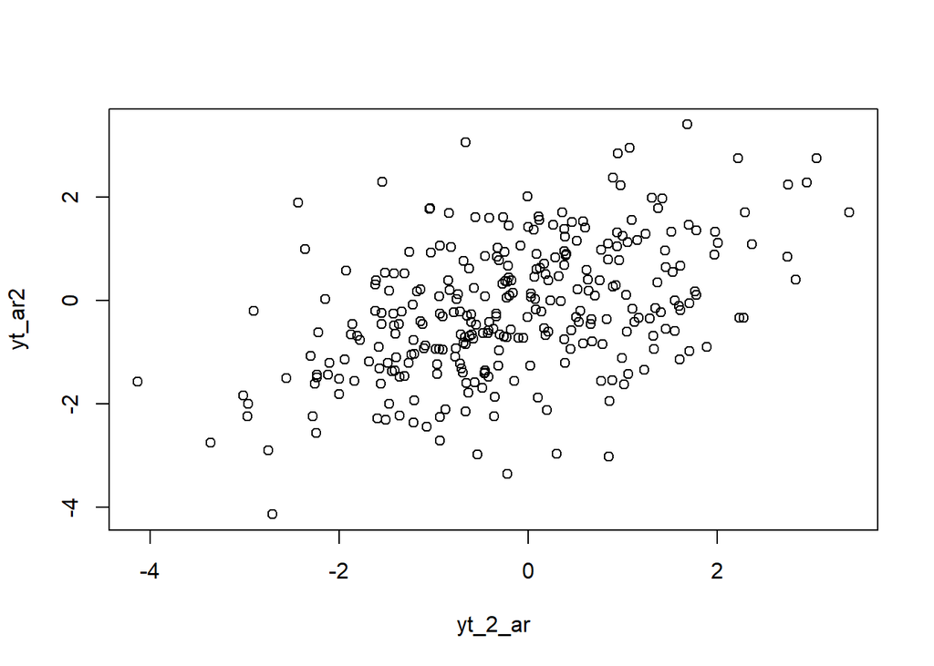

```r
plot(y=yt_ar2,x=yt_2_ar)
```

```r
cor(yt_ar2,yt_2_ar)
```

```
## [1] 0.462009
```

####Korelasi antara $Y_t$ dengan $Y_{t-3}$

```r
#Yt
yt_ar3 <- ar[-c(1,2,3)]
yt_ar3
```

```
##   [1]  1.784619084  1.291686916  0.105662673 -0.350122073 -1.877523754
##   [6] -1.863803390 -0.657765088 -0.463962118 -1.596790168 -1.414411664
##  [11] -2.282052112 -1.359483292 -2.244713772 -2.222591630 -2.563524708
##  [16] -0.614399085 -1.509945818 -0.691956531 -2.304505798 -1.399841912
##  [21] -1.072933323 -1.101263776 -2.436686453 -0.931220206  1.891585437
##  [26]  1.059712833 -0.907225867 -1.421720938 -0.308397269 -0.482529306
##  [31]  0.772138706 -1.685596517 -1.558615912 -1.178720673 -1.615798351
##  [36]  0.170312359  0.305649433 -0.535367198 -2.961802067 -2.975912909
##  [41] -2.001823031 -2.240192648 -1.808149222 -1.430580889 -0.681655194
##  [46] -0.251062722 -0.816434647  0.942392425  1.036988108  1.308899032
##  [51]  0.111477925  1.981675295  1.616295548  1.328958603  0.663583897
##  [56] -0.681096707 -0.452835594  0.761192978  0.073108845  0.381853653
##  [61]  0.019838852 -0.757826590 -1.256317093  0.030781486  0.939632522
##  [66]  0.067691753  1.045321653  0.457695594 -0.602145821 -0.573266396
##  [71] -0.271652114  0.236166595  0.322879110 -0.006570867  0.465722631
```

[output cut: 45 more lines]

```r
#Yt-2
yt_3_ar <- ar[-c(298,299,300)]
yt_3_ar
```

```
##   [1]  1.000000000 -1.039495666  1.243458595  1.784619084  1.291686916
##   [6]  0.105662673 -0.350122073 -1.877523754 -1.863803390 -0.657765088
##  [11] -0.463962118 -1.596790168 -1.414411664 -2.282052112 -1.359483292
##  [16] -2.244713772 -2.222591630 -2.563524708 -0.614399085 -1.509945818
##  [21] -0.691956531 -2.304505798 -1.399841912 -1.072933323 -1.101263776
##  [26] -2.436686453 -0.931220206  1.891585437  1.059712833 -0.907225867
##  [31] -1.421720938 -0.308397269 -0.482529306  0.772138706 -1.685596517
##  [36] -1.558615912 -1.178720673 -1.615798351  0.170312359  0.305649433
##  [41] -0.535367198 -2.961802067 -2.975912909 -2.001823031 -2.240192648
##  [46] -1.808149222 -1.430580889 -0.681655194 -0.251062722 -0.816434647
##  [51]  0.942392425  1.036988108  1.308899032  0.111477925  1.981675295
##  [56]  1.616295548  1.328958603  0.663583897 -0.681096707 -0.452835594
##  [61]  0.761192978  0.073108845  0.381853653  0.019838852 -0.757826590
##  [66] -1.256317093  0.030781486  0.939632522  0.067691753  1.045321653
##  [71]  0.457695594 -0.602145821 -0.573266396 -0.271652114  0.236166595
```

[output cut: 45 more lines]

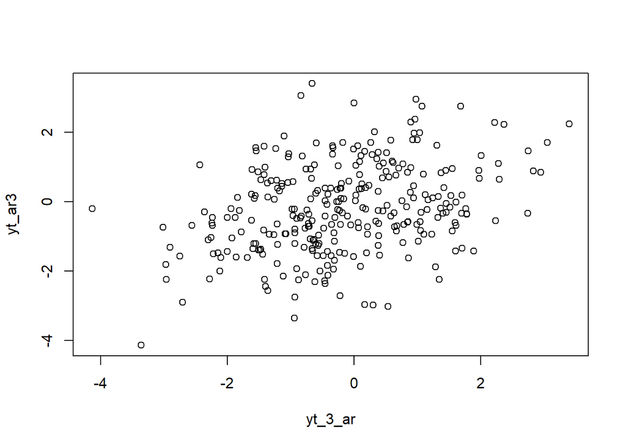

```r
plot(y=yt_ar3,x=yt_3_ar)
```

```r
cor(yt_ar2,yt_2_ar)
```

```
## [1] 0.462009
```

## Fungsi pembangkitan ARMA

Jika koefisien dan *white noise*/nilai deret waktu sebelumnya dapat diekstrak dalam bentuk vektor, dapat dilakukan perkalian matriks untuk mencari nilai bagian AR dan MA:

```r
set.seed(060)
n = length(wn)
phi1 = 0.5
phi2 = 0.2
teta1 = 0.4
teta2 = 0.6

y.arma=c(1:n)
for (i in 3:n){y.arma[i] = phi1*y.arma[i-1] + teta1*wn[i-1]+wn[i] + phi2*y.arma[i-2] + teta2*wn[i-2]+wn[i]}
y.arma
```

```
##   [1]   1.000000000   2.000000000   3.348235059   3.647258490   4.126525935
##   [6]   1.761178592   0.563787462  -3.279492436  -3.533489137  -2.328126173
##  [11]  -1.948777170  -3.597319442  -3.292654856  -5.831592640  -3.793201626
##  [16]  -6.329067370  -5.600216265  -7.117704817  -3.112618661  -5.272182267
##  [21]  -2.252509439  -6.322881284  -3.694369403  -4.304605805  -3.500827989
##  [26]  -6.138849345  -3.097116642   1.620854011   1.144261750  -0.981443064
##  [31]  -2.653442968  -1.453475365  -1.988003455   1.240545586  -3.945542163
##  [36]  -2.706550578  -3.804898298  -4.287441848  -0.670849447  -0.773919374
##  [41]  -1.164378144  -6.098933254  -6.572056273  -6.256470378  -6.629543971
##  [46]  -5.332871806  -4.921453227  -3.097757312  -2.052002763  -2.644645104
##  [51]   1.174451503   1.034067777   2.977202274   0.545502887   4.703377248
##  [56]   3.197640344   4.168432645   2.406864535  -0.242235891  -0.210135285
##  [61]   1.325050545   0.146676155   1.462719350   0.122212738  -1.090354340
##  [66]  -2.429572320  -0.365813791   1.095927898   0.208055429   2.633919030
##  [71]   0.855655837  -0.401303118  -0.866479867  -0.868457202   0.205916729
```

[output cut: 45 more lines]

```r
arma11 <- arima.sim(list(order=c(2,0,2), ar = c(0.5, 0.2), ma = c(0.4, 0.6)), n=300)
arma11
```

```
## Time Series:
## Start = 1
## End = 300
## Frequency = 1
##   [1] -0.439160158  1.411949086  2.070293420  2.997330598  4.408175304
##   [6]  3.167385381  2.854733885  2.142883727 -0.028232012 -0.738363966
##  [11] -2.507665343 -1.845287143 -1.999990224  0.622609398  1.733693609
##  [16]  2.972891012  3.111061830  3.117685282  3.680079021  1.062085322
##  [21]  1.097071369  1.659821318  2.857528417  5.128208881  5.980688190
##  [26]  6.766958905  5.927849013  5.412419956  2.652719387  1.835773131
##  [31]  0.468809226 -0.183469609 -0.188798169 -0.476500027 -1.528299561
##  [36] -2.359038242 -4.359249171 -2.752629239 -2.344715889 -1.319125562
##  [41] -1.600249030 -0.772714404  0.174200681  1.550650223  2.308063459
##  [46]  2.135466309  2.409414418  1.957138238  2.375810212  2.083457572
##  [51]  0.798051161 -0.017811509 -1.702255950 -1.318887089  0.212994172
```

[output cut: 49 more lines]

## Karakteristik ARMA(2,2)

### Plot Time Series

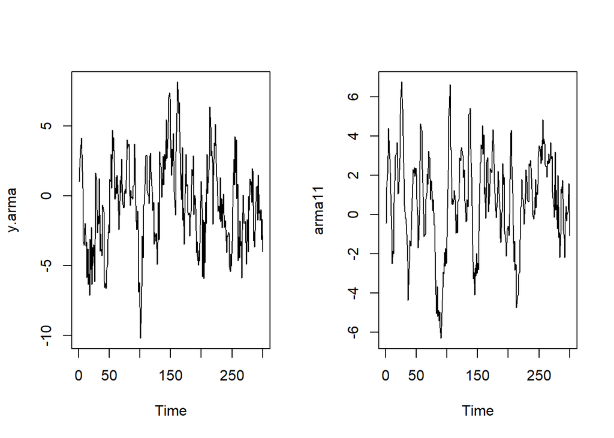

```r
par(mfrow = c(1, 2))
ts.plot(y.arma)
ts.plot(arma11)
```

```r
par(mfrow = c(1, 1))
```

Berdasarkan plot time series tersebut, terlihat bahwa model ARMA(2,2) cenderung stasioner dalam rataan

###Plot ACF

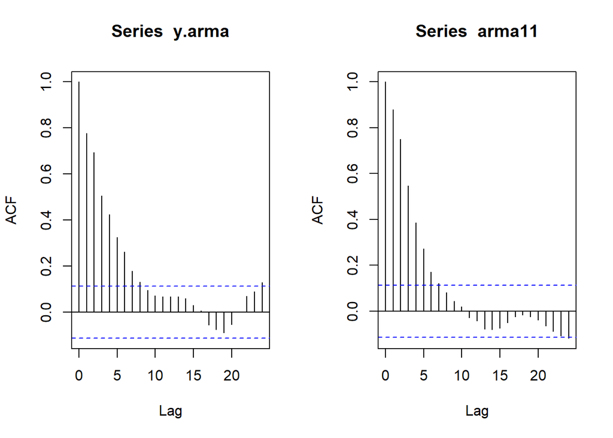

```r
par(mfrow = c(1, 2))
acf(y.arma)
acf(arma11)
```

```r
par(mfrow = c(1, 1))
```

###Plot PACF

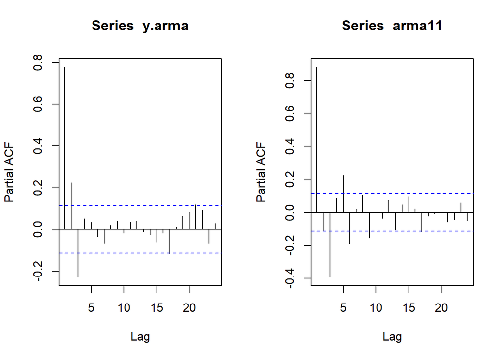

```r
par(mfrow = c(1, 2))
pacf(y.arma)
pacf(arma11)
```

```r
par(mfrow = c(1, 1))
```

###Plot EACF

```r
TSA::eacf(y.arma)
```

```
## AR/MA
##   0 1 2 3 4 5 6 7 8 9 10 11 12 13
## 0 x x x x x x x x o o o  o  o  o
## 1 x x x o o o o o o o o  o  o  o
## 2 x x o o o o o o o o o  o  o  o
## 3 x x o o o o o o o o o  o  o  o
## 4 x x o o o o o o o o o  o  o  o
## 5 x x o x o o o o o o o  o  o  o
## 6 x x x x o o o o o o o  o  o  o
## 7 x x x x o x o o o o o  o  o  o
```

```r
TSA::eacf(arma11)
```

```
## AR/MA
##   0 1 2 3 4 5 6 7 8 9 10 11 12 13
## 0 x x x x x x x o o o o  o  o  o
## 1 x x o o o o o o o o o  o  x  o
## 2 x x o o o o o o o o o  o  x  o
## 3 x x o x o o o o o x o  o  o  o
## 4 x x x o o o o o o o o  o  x  o
## 5 x x x o o o o o o o o  o  o  o
## 6 o x o x o o x x o o o  o  o  o
## 7 x x x o o o x x o o o  x  o  o
```

###Scatterplot Antar Lag ####Korelasi antara $Y_t$ dengan $Y_{t-1}$

```r
#Yt
yt_arma <- arma11[-1]
yt_arma
```

```
##   [1]  1.411949086  2.070293420  2.997330598  4.408175304  3.167385381
##   [6]  2.854733885  2.142883727 -0.028232012 -0.738363966 -2.507665343
##  [11] -1.845287143 -1.999990224  0.622609398  1.733693609  2.972891012
##  [16]  3.111061830  3.117685282  3.680079021  1.062085322  1.097071369
##  [21]  1.659821318  2.857528417  5.128208881  5.980688190  6.766958905
##  [26]  5.927849013  5.412419956  2.652719387  1.835773131  0.468809226
##  [31] -0.183469609 -0.188798169 -0.476500027 -1.528299561 -2.359038242
##  [36] -4.359249171 -2.752629239 -2.344715889 -1.319125562 -1.600249030
##  [41] -0.772714404  0.174200681  1.550650223  2.308063459  2.135466309
##  [46]  2.409414418  1.957138238  2.375810212  2.083457572  0.798051161
##  [51] -0.017811509 -1.702255950 -1.318887089  0.212994172  2.758702828
##  [56]  4.628136416  4.393286233  4.309646416  2.329615788  0.920247145
##  [61]  0.054152407 -1.114733107 -1.009479418 -0.984126566  0.788222023
##  [66]  1.107920136  2.084856343  1.544891055  3.249881790  2.925577367
##  [71]  2.922756437  0.775918750  1.270555164  1.731053002  0.670982343
```

[output cut: 45 more lines]

```r
#Yt-1
yt_1_arma <- arma11[-300]
yt_1_arma
```

```
##   [1] -0.439160158  1.411949086  2.070293420  2.997330598  4.408175304
##   [6]  3.167385381  2.854733885  2.142883727 -0.028232012 -0.738363966
##  [11] -2.507665343 -1.845287143 -1.999990224  0.622609398  1.733693609
##  [16]  2.972891012  3.111061830  3.117685282  3.680079021  1.062085322
##  [21]  1.097071369  1.659821318  2.857528417  5.128208881  5.980688190
##  [26]  6.766958905  5.927849013  5.412419956  2.652719387  1.835773131
##  [31]  0.468809226 -0.183469609 -0.188798169 -0.476500027 -1.528299561
##  [36] -2.359038242 -4.359249171 -2.752629239 -2.344715889 -1.319125562
##  [41] -1.600249030 -0.772714404  0.174200681  1.550650223  2.308063459
##  [46]  2.135466309  2.409414418  1.957138238  2.375810212  2.083457572
##  [51]  0.798051161 -0.017811509 -1.702255950 -1.318887089  0.212994172
##  [56]  2.758702828  4.628136416  4.393286233  4.309646416  2.329615788
##  [61]  0.920247145  0.054152407 -1.114733107 -1.009479418 -0.984126566
##  [66]  0.788222023  1.107920136  2.084856343  1.544891055  3.249881790
##  [71]  2.925577367  2.922756437  0.775918750  1.270555164  1.731053002
```

[output cut: 45 more lines]

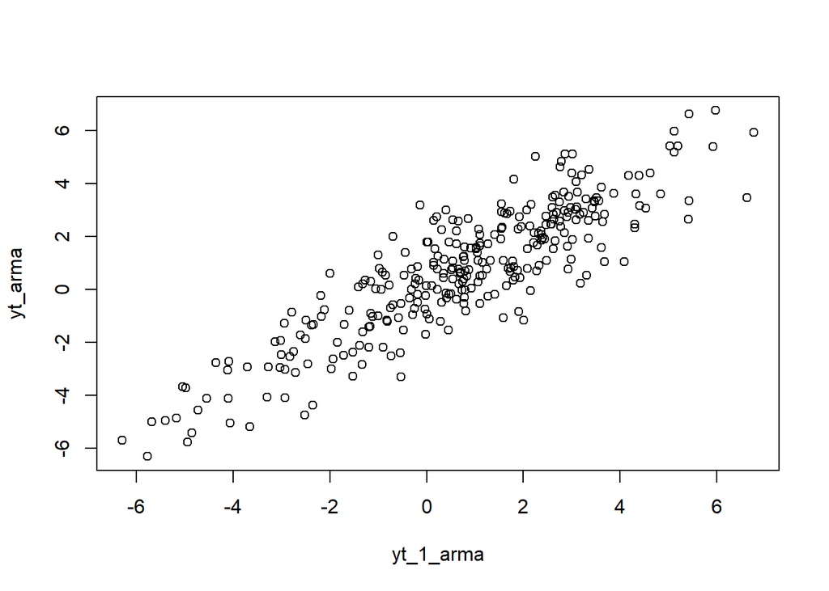

```r
plot(y=yt_arma,x=yt_1_arma)
```

```r
cor(yt_arma,yt_1_arma)
```

```
## [1] 0.8812761
```

####Korelasi antara $Y_t$ dengan $Y_{t-2}$

```r
#Yt
yt_arma2 <- arma11[-c(1,2)]
yt_arma2
```

```
##   [1]  2.070293420  2.997330598  4.408175304  3.167385381  2.854733885
##   [6]  2.142883727 -0.028232012 -0.738363966 -2.507665343 -1.845287143
##  [11] -1.999990224  0.622609398  1.733693609  2.972891012  3.111061830
##  [16]  3.117685282  3.680079021  1.062085322  1.097071369  1.659821318
##  [21]  2.857528417  5.128208881  5.980688190  6.766958905  5.927849013
##  [26]  5.412419956  2.652719387  1.835773131  0.468809226 -0.183469609
##  [31] -0.188798169 -0.476500027 -1.528299561 -2.359038242 -4.359249171
##  [36] -2.752629239 -2.344715889 -1.319125562 -1.600249030 -0.772714404
##  [41]  0.174200681  1.550650223  2.308063459  2.135466309  2.409414418
##  [46]  1.957138238  2.375810212  2.083457572  0.798051161 -0.017811509
##  [51] -1.702255950 -1.318887089  0.212994172  2.758702828  4.628136416
##  [56]  4.393286233  4.309646416  2.329615788  0.920247145  0.054152407
##  [61] -1.114733107 -1.009479418 -0.984126566  0.788222023  1.107920136
##  [66]  2.084856343  1.544891055  3.249881790  2.925577367  2.922756437
##  [71]  0.775918750  1.270555164  1.731053002  0.670982343  0.218830143
```

[output cut: 45 more lines]

```r
#Yt-2
yt_2_arma <- arma11[-c(299,300)]
yt_2_arma
```

```
##   [1] -0.439160158  1.411949086  2.070293420  2.997330598  4.408175304
##   [6]  3.167385381  2.854733885  2.142883727 -0.028232012 -0.738363966
##  [11] -2.507665343 -1.845287143 -1.999990224  0.622609398  1.733693609
##  [16]  2.972891012  3.111061830  3.117685282  3.680079021  1.062085322
##  [21]  1.097071369  1.659821318  2.857528417  5.128208881  5.980688190
##  [26]  6.766958905  5.927849013  5.412419956  2.652719387  1.835773131
##  [31]  0.468809226 -0.183469609 -0.188798169 -0.476500027 -1.528299561
##  [36] -2.359038242 -4.359249171 -2.752629239 -2.344715889 -1.319125562
##  [41] -1.600249030 -0.772714404  0.174200681  1.550650223  2.308063459
##  [46]  2.135466309  2.409414418  1.957138238  2.375810212  2.083457572
##  [51]  0.798051161 -0.017811509 -1.702255950 -1.318887089  0.212994172
##  [56]  2.758702828  4.628136416  4.393286233  4.309646416  2.329615788
##  [61]  0.920247145  0.054152407 -1.114733107 -1.009479418 -0.984126566
##  [66]  0.788222023  1.107920136  2.084856343  1.544891055  3.249881790
##  [71]  2.925577367  2.922756437  0.775918750  1.270555164  1.731053002
```

[output cut: 45 more lines]

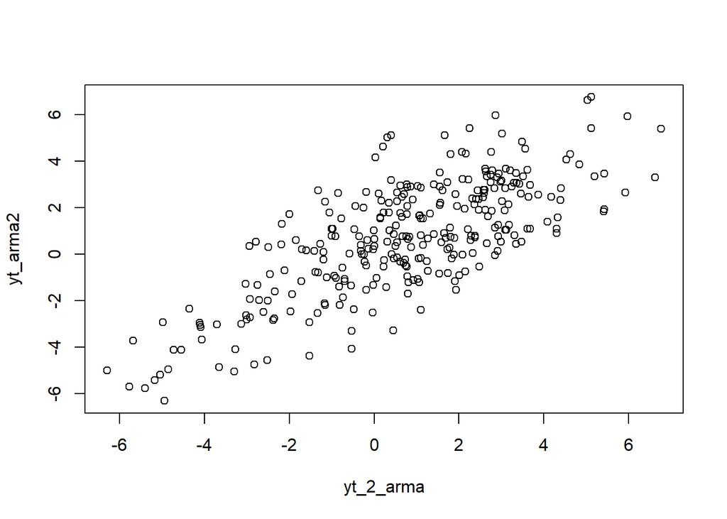

```r
plot(y=yt_arma2,x=yt_2_arma)
```

```r
cor(yt_arma2,yt_2_arma)
```

```
## [1] 0.7507678
```

####Korelasi antara $Y_t$ dengan $Y_{t-3}$

```r
#Yt
yt_arma3 <- arma11[-c(1,2,3)]
yt_arma3
```

```
##   [1]  2.997330598  4.408175304  3.167385381  2.854733885  2.142883727
##   [6] -0.028232012 -0.738363966 -2.507665343 -1.845287143 -1.999990224
##  [11]  0.622609398  1.733693609  2.972891012  3.111061830  3.117685282
##  [16]  3.680079021  1.062085322  1.097071369  1.659821318  2.857528417
##  [21]  5.128208881  5.980688190  6.766958905  5.927849013  5.412419956
##  [26]  2.652719387  1.835773131  0.468809226 -0.183469609 -0.188798169
##  [31] -0.476500027 -1.528299561 -2.359038242 -4.359249171 -2.752629239
##  [36] -2.344715889 -1.319125562 -1.600249030 -0.772714404  0.174200681
##  [41]  1.550650223  2.308063459  2.135466309  2.409414418  1.957138238
##  [46]  2.375810212  2.083457572  0.798051161 -0.017811509 -1.702255950
##  [51] -1.318887089  0.212994172  2.758702828  4.628136416  4.393286233
##  [56]  4.309646416  2.329615788  0.920247145  0.054152407 -1.114733107
##  [61] -1.009479418 -0.984126566  0.788222023  1.107920136  2.084856343
##  [66]  1.544891055  3.249881790  2.925577367  2.922756437  0.775918750
##  [71]  1.270555164  1.731053002  0.670982343  0.218830143  0.775736270
```

[output cut: 45 more lines]

```r
#Yt-3
yt_3_arma <- arma11[-c(298,299,300)]
yt_3_arma
```

```
##   [1] -0.439160158  1.411949086  2.070293420  2.997330598  4.408175304
##   [6]  3.167385381  2.854733885  2.142883727 -0.028232012 -0.738363966
##  [11] -2.507665343 -1.845287143 -1.999990224  0.622609398  1.733693609
##  [16]  2.972891012  3.111061830  3.117685282  3.680079021  1.062085322
##  [21]  1.097071369  1.659821318  2.857528417  5.128208881  5.980688190
##  [26]  6.766958905  5.927849013  5.412419956  2.652719387  1.835773131
##  [31]  0.468809226 -0.183469609 -0.188798169 -0.476500027 -1.528299561
##  [36] -2.359038242 -4.359249171 -2.752629239 -2.344715889 -1.319125562
##  [41] -1.600249030 -0.772714404  0.174200681  1.550650223  2.308063459
##  [46]  2.135466309  2.409414418  1.957138238  2.375810212  2.083457572
##  [51]  0.798051161 -0.017811509 -1.702255950 -1.318887089  0.212994172
##  [56]  2.758702828  4.628136416  4.393286233  4.309646416  2.329615788
##  [61]  0.920247145  0.054152407 -1.114733107 -1.009479418 -0.984126566
##  [66]  0.788222023  1.107920136  2.084856343  1.544891055  3.249881790
##  [71]  2.925577367  2.922756437  0.775918750  1.270555164  1.731053002
```

[output cut: 45 more lines]

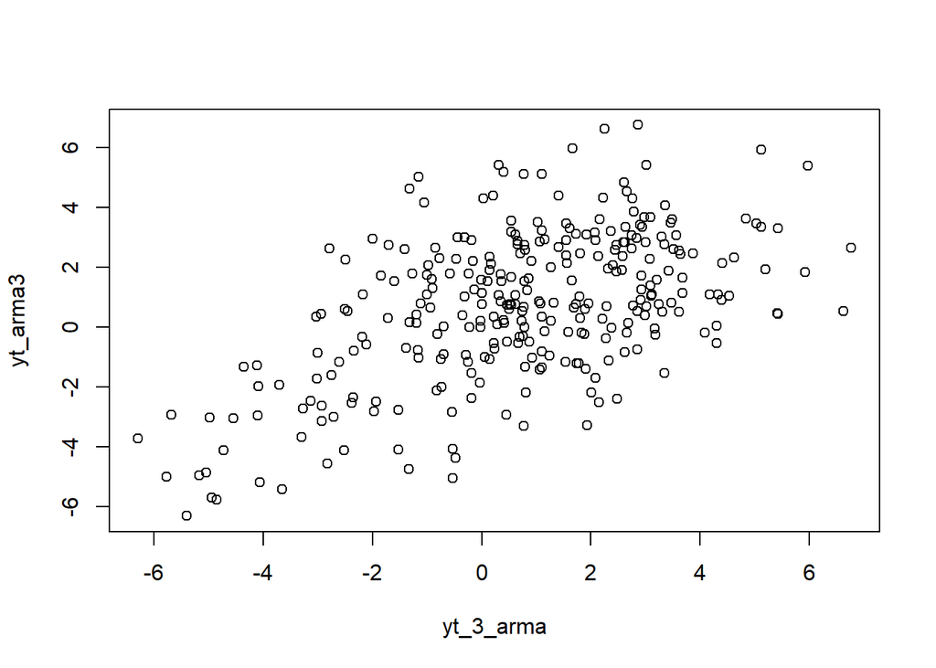

```r
plot(y=yt_arma3,x=yt_3_arma)
```

```r
cor(yt_arma3,yt_3_arma)
```

```
## [1] 0.5487856
```